# Sentiment Analysis: Wendy’s vs. McDonald’s

Author

Levi Sayles

Published

December 5, 2024

## Introduction

In today’s competitive fast-food industry, understanding public sentiment is crucial for driving customer engagement and improving brand reputation. This report investigates the sentiment and emotions expressed in online discussions about two iconic fast-food chains: **Wendy’s** and **McDonald’s**. By leveraging sentiment analysis techniques and the NRC lexicon, we aim to uncover valuable insights into how these brands are perceived by their audiences.

### **Key Questions:**

1. **Sentiment Comparison**: How do positive and negative sentiments differ between Wendy’s and McDonald’s?
2. **Emotional Landscape**: What are the dominant emotions associated with each brand, and how do they vary?
3. **Sentiment Trends**: How has sentiment for each brand evolved over time, and what factors might have influenced these trends?

The findings of this analysis will provide actionable insights to help these brands better understand their customers and optimize their marketing and public relations strategies.

## Data Collection

For this analysis, data was collected using **Google News RSS feeds**, capturing articles that specifically mention **“Wendy’s”** and **“McDonald’s”**. These articles provide unstructured textual data reflecting public discussions and opinions about each brand.

### **Processing Steps:**

1. Articles were retrieved and stored in CSV files for analysis.
2. The text data from titles and descriptions of the articles were combined to form a comprehensive text column for each brand.
3. Sentiment and emotional context were analyzed using the **NRC lexicon** to categorize words into predefined sentiment and emotion classes.

This approach ensures that the analysis captures diverse and meaningful public discourse, offering an accurate view of brand perception over time.

## Question 1: Positive vs. Negative Sentiments

**Question:** Are discussions about Wendy’s generally more positive or negative compared to McDonald’s?

**Rationale:** This helps gauge overall public perception of each brand.

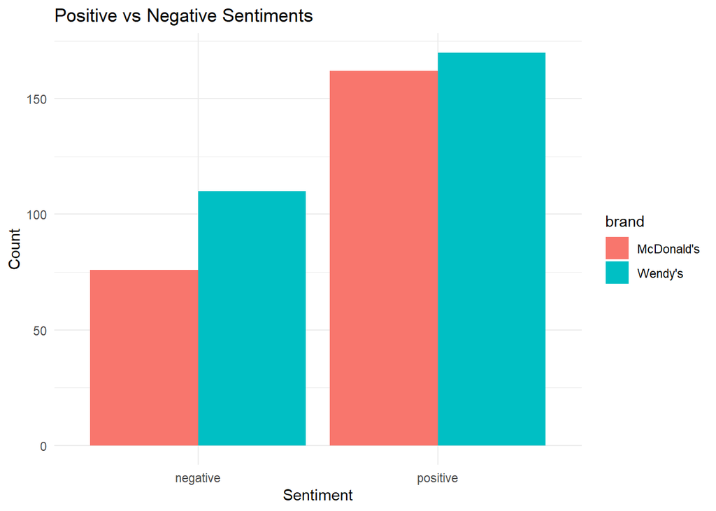

### Implications:

- Wendy’s strong positive sentiment indicates a favorable public perception.
- Wendy’s should focus on reducing negative sentiment through improved customer engagement and public relations strategies.

## Question 2: Dominant Emotions

**Question:** What emotions dominate for Wendy’s and McDonald’s?

**Rationale:** Understanding emotional responses helps identify strengths and weaknesses in public perception.

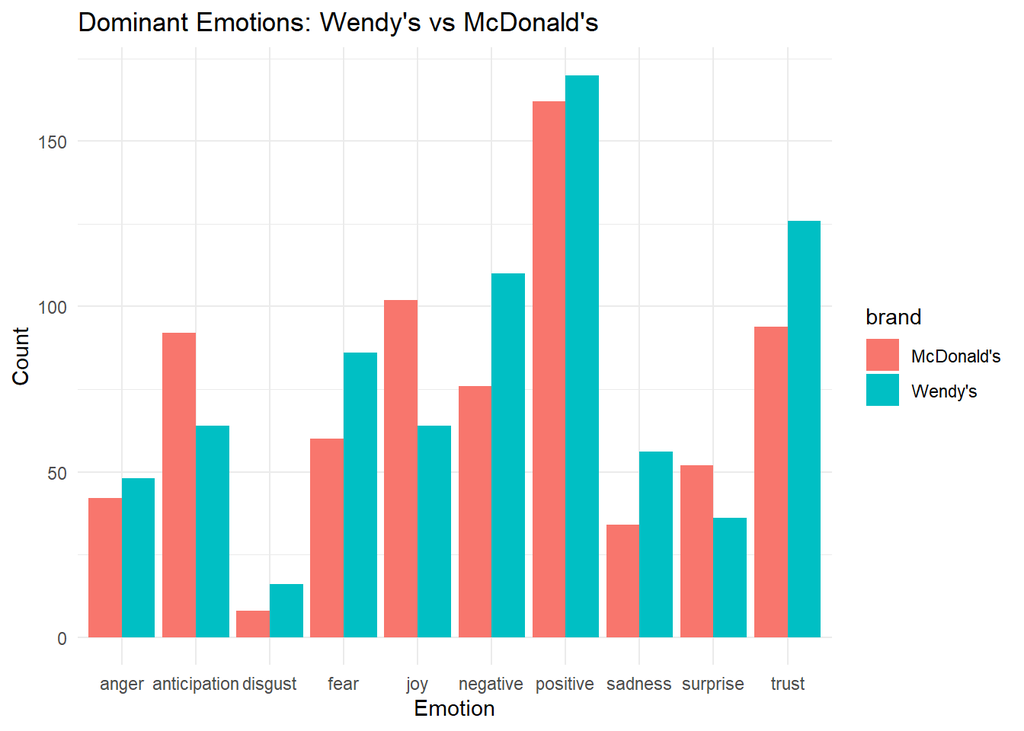

### Key Observations:

**Positive Emotions:**

- Wendy’s has higher counts for “trust” than McDonald’s, reflecting stronger public approval.
- McDonald’s shows significant “anticipation,” suggesting customer excitement.

**Negative Emotions:**

- Wendy’s leads in “negative,” “fear,” and “sadness,” indicating areas of concern or dissatisfaction.
- McDonald’s has lower counts for “disgust” compared to Wendy’s.

**Implications:**

- Wendy’s can capitalize on its strong “trust” and “positive”sentiments.
- Wendy’s should investigate and address the root causes of “fear” and “sadness” to improve customer sentiment.

## Question 3: Sentiment Trends Over Time

**Question:** How has sentiment for Wendy’s and McDonald’s evolved over time?

**Rationale:** Tracking sentiment over time reveals trends and potential reactions to events.

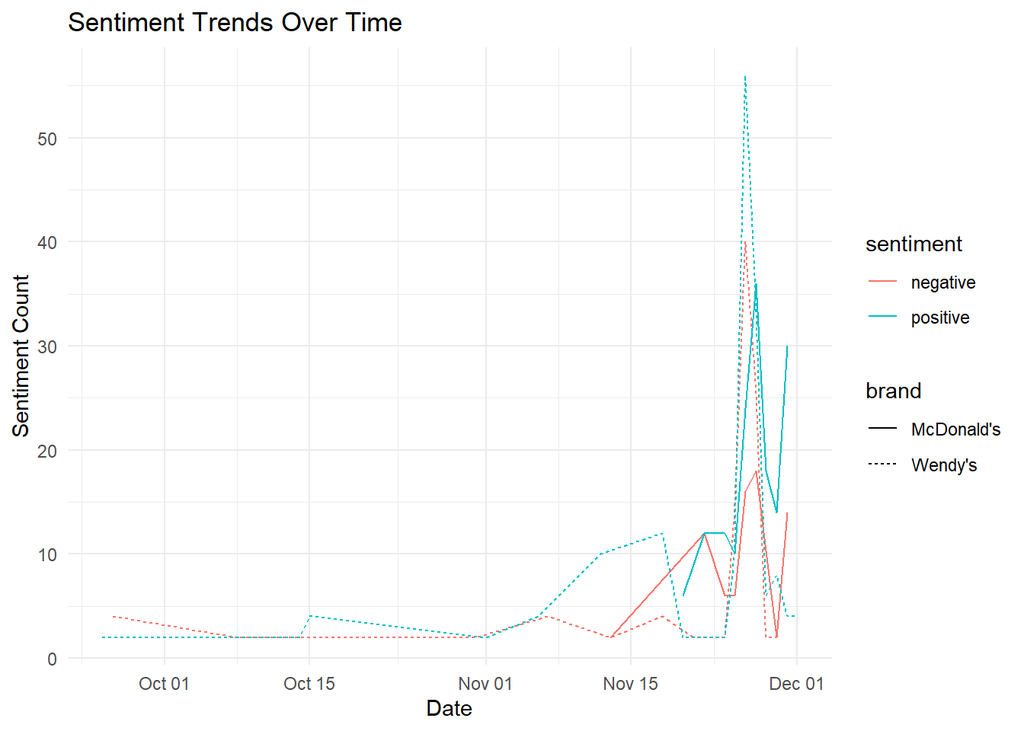

## Conclusion

These findings can guide marketing strategies and public relations efforts for both brands.